# Cyclistic Bikeshare DataAnalysis Case study

Yannadatch.O

28/07/2021

by: Yannadatch Ouchalern,

[figure not shown]

## Table of Contents.

- Purpose Statement (What are we talking about ?)
- Prepare & Process Data
- Analyze & Visualization
- Conclusion
- Recommendation
- Appendix

## What are we talking about ?

### Introduction

In 2016, Cyclistic launched a successful bike-share offering. Since then, the program has grown to a fleet of **5,824 bicycles** that are geotracked and locked into a network of **692 stations** across **Chicago**. The bikes can be unlocked from one station and returned to any other station in the system anytime.

Until now, Cyclistic’s marketing strategy relied on building general awareness and appealing to broad consumer segments. One approach that helped make these things possible was the flexibility of its pricing plans: **single-ride passes**, **full-day passes**, and **annual memberships**.

Customers who purchase `single-ride` or `full-day passes` are referred to as **casual riders**. Customers who purchase `annual memberships` are **Cyclistic members**.

The director of marketing has set a clear goal: Design marketing strategies aimed at **converting casual riders** into **annual members**

### ASK Process

1. Marketing team are interested in analyzing the Cyclistic historical bike trip data to **identify trends**.
2. The marketing analyst team needs to better understand **how annual members and casual riders differ** ?
3. **Why casual riders would buy a membership** ?
4. **How digital media could affect their marketing tactics ?**

### Objective

Design marketing strategies aimed at **converting casual riders** into **annual members**

## Prepare & Process Data

### Import library

```r
#import library:
library(tidyverse)
library(ggplot2)
library(sqldf)
library(janitor) #for clean_names()
library(lubridate)
library(dplyr)
library(ggcorrplot)
library(here)
library(knitr) #for prop table
library(zoo) #tranfom data : yearqtr
library(leaflet) #library for basic map



theme_set(theme_minimal())
```

### Import dataset

#### Import dataset of 2014 and cleaning data

```r
#import dataset
trips_2014_Q1Q2 <- read.csv('Divvy_Trips_2014_Q1Q2.csv')
trips_2014_Q307 <- read.csv('Divvy_Trips_2014-Q3-07.csv')
trips_2014_Q30809 <- read.csv('Divvy_Trips_2014-Q3-0809.csv')
trips_2014_Q4 <- read.csv('Divvy_Trips_2014-Q4.csv')
```

```r
#clean columns name : make sure that columns names are unique and change data type of columns to suitable format

trips_2014_Q1Q2 <- clean_names(trips_2014_Q1Q2) %>%
                   mutate(from_station_id = as.character(from_station_id),
                          to_station_id = as.character(to_station_id),
                          starttime = mdy_hm(starttime),
                          stoptime = mdy_hm(stoptime))

trips_2014_Q307 <- clean_names(trips_2014_Q307) %>%
                   mutate(from_station_id = as.character(from_station_id),
                          to_station_id = as.character(to_station_id),
                          starttime = mdy_hm(starttime),
                          stoptime = mdy_hm(stoptime))

trips_2014_Q30809 <- clean_names(trips_2014_Q30809) %>%
                     mutate(from_station_id = as.character(from_station_id),
                           to_station_id = as.character(to_station_id),
                           starttime = mdy_hm(starttime),
                           stoptime = mdy_hm(stoptime))

trips_2014_Q4 <- clean_names(trips_2014_Q4) %>%
                 mutate(from_station_id = as.character(from_station_id),
                        to_station_id = as.character(to_station_id),
                        starttime = mdy_hm(starttime),
                        stoptime = mdy_hm(stoptime))
```

```r
#join all data into data frame
trips_2014 <- bind_rows(trips_2014_Q1Q2, trips_2014_Q307, trips_2014_Q30809, trips_2014_Q4)
#glimpse(trips_2014)
```

```r
#Transform data add columns 'ride_length_mins', 'day_of_week'
Sys.setlocale("LC_TIME", "English")
```

```
## [1] "English_United States.1252"
```

```r
trips_2014_v2 <- trips_2014 %>%
                 select(-tripduration) %>%
                 mutate(ride_length_mins = difftime(stoptime, starttime, units = "mins")) %>%
                 mutate(day_of_week = wday(starttime, label = TRUE, abbr = FALSE))

#glimpse(trips_2014_v2)
```

#### Import dataset of 2015 and cleaning data

```r
#import dataset
trips_2015_Q1 <- read.csv('Divvy_Trips_2015-Q1.csv')
trips_2015_Q2 <- read.csv('Divvy_Trips_2015-Q2.csv')
trips_2015_07 <- read.csv('Divvy_Trips_2015_07.csv')
trips_2015_08 <- read.csv('Divvy_Trips_2015_08.csv')
trips_2015_09 <- read.csv('Divvy_Trips_2015_09.csv')
trips_2015_Q4 <- read.csv('Divvy_Trips_2015_Q4.csv')
```

```r
#glimpse(trips_2015_Q4)
```

```r
#clean columns name : make sure that columns names are unique and change data type of columns to suitable format
trips_2015_Q1 <- clean_names(trips_2015_Q1) %>%
                   mutate(from_station_id = as.character(from_station_id),
                          to_station_id = as.character(to_station_id),
                          starttime = mdy_hm(starttime),
                          stoptime = mdy_hm(stoptime))

trips_2015_Q2 <- clean_names(trips_2015_Q2) %>%
                   mutate(from_station_id = as.character(from_station_id),
                          to_station_id = as.character(to_station_id),
                          starttime = mdy_hm(starttime),
                          stoptime = mdy_hm(stoptime))

trips_2015_07 <- clean_names(trips_2015_07) %>%
                   mutate(from_station_id = as.character(from_station_id),
                          to_station_id = as.character(to_station_id),
                          starttime = mdy_hm(starttime),
                          stoptime = mdy_hm(stoptime))

trips_2015_08 <- clean_names(trips_2015_08) %>%
                   mutate(from_station_id = as.character(from_station_id),
                          to_station_id = as.character(to_station_id),
                          starttime = mdy_hm(starttime),
                          stoptime = mdy_hm(stoptime))

trips_2015_09 <- clean_names(trips_2015_09) %>%
                   mutate(from_station_id = as.character(from_station_id),
                          to_station_id = as.character(to_station_id),
                          starttime = mdy_hm(starttime),
                          stoptime = mdy_hm(stoptime))

trips_2015_Q4 <- clean_names(trips_2015_Q4) %>%
                   mutate(from_station_id = as.character(from_station_id),
                          to_station_id = as.character(to_station_id),
                          starttime = mdy_hm(starttime),
                          stoptime = mdy_hm(stoptime))
```

```r
#join all data into dataframe
trips_2015 <- bind_rows(trips_2015_Q1,trips_2015_Q2,trips_2015_07,trips_2015_08,trips_2015_09,trips_2015_Q4)
#glimpse(trips_2015)
```

```r
#Transform data add columns 'ride_length_mins', 'day_of_week'
trips_2015_v2 <- trips_2015 %>%
                 select(-tripduration) %>%
                 mutate(ride_length_mins = difftime(stoptime, starttime, units = "mins")) %>%
                 mutate(day_of_week = wday(starttime, label = TRUE, abbr = FALSE))

#glimpse(trips_2015_v2)
```

#### Import dataset of 2016 and cleaning data

```r
#import dataset
trips_2016_Q1 <- read.csv('Divvy_Trips_2016_Q1.csv')
trips_2016_04 <- read.csv('Divvy_Trips_2016_04.csv')
trips_2016_05 <- read.csv('Divvy_Trips_2016_05.csv')
trips_2016_06 <- read.csv('Divvy_Trips_2016_06.csv')
trips_2016_Q3 <- read.csv('Divvy_Trips_2016_Q3.csv')
trips_2016_Q4 <- read.csv('Divvy_Trips_2016_Q4.csv')
```

```r
#clean columns name : make sure that columns names are unique and change data type of columns to suitable format
trips_2016_Q1 <- clean_names(trips_2016_Q1) %>%
                 mutate(from_station_id = as.character(from_station_id),
                        to_station_id = as.character(to_station_id),
                        starttime = mdy_hm(starttime),
                        stoptime = mdy_hm(stoptime))

trips_2016_04 <- clean_names(trips_2016_04) %>%
                 mutate(from_station_id = as.character(from_station_id),
                        to_station_id = as.character(to_station_id),
                        starttime = mdy_hm(starttime),
                        stoptime = mdy_hm(stoptime))

trips_2016_05 <- clean_names(trips_2016_05) %>%
                 mutate(from_station_id = as.character(from_station_id),
                        to_station_id = as.character(to_station_id),
                        starttime = mdy_hm(starttime),
                        stoptime = mdy_hm(stoptime))

trips_2016_06 <- clean_names(trips_2016_06) %>%
                 mutate(from_station_id = as.character(from_station_id),
                        to_station_id = as.character(to_station_id),
                        starttime = mdy_hm(starttime),
                        stoptime = mdy_hm(stoptime))

trips_2016_Q3 <- clean_names(trips_2016_Q3) %>%
                 mutate(from_station_id = as.character(from_station_id),
                        to_station_id = as.character(to_station_id),
                        starttime = mdy_hms(starttime),
                        stoptime = mdy_hms(stoptime))

trips_2016_Q4 <- clean_names(trips_2016_Q4) %>%
                 mutate(from_station_id = as.character(from_station_id),
                        to_station_id = as.character(to_station_id),
                        starttime = mdy_hms(starttime),
                        stoptime = mdy_hms(stoptime))
```

```r
#join all data into dataframe
trips_2016 <- bind_rows(trips_2016_Q1,trips_2016_04,trips_2016_05,trips_2016_06,trips_2016_Q3,trips_2016_Q4)
#glimpse(trips_2016)
```

```r
#Transform data add columns 'ride_length_mins', 'day_of_week'
#Sys.setlocale("LC_TIME", "English")
trips_2016_v2 <- trips_2016 %>%
                 select(-tripduration) %>%
                 mutate(ride_length_mins = difftime(stoptime, starttime, units = "mins")) %>%
                 mutate(day_of_week = wday(starttime, label = TRUE, abbr = FALSE))  %>%
                 drop_na() %>%  filter(ride_length_mins > 0)

#glimpse(trips_2016_v2)
```

#### Import dataset of 2017 and cleaning data

```r
#import dataset
trips_2017_Q1 <- read.csv('Divvy_Trips_2017_Q1.csv')
trips_2017_Q2 <- read.csv('Divvy_Trips_2017_Q2.csv')
trips_2017_Q3 <- read.csv('Divvy_Trips_2017_Q3.csv')
trips_2017_Q4 <- read.csv('Divvy_Trips_2017_Q4.csv')
```

```r
#clean columns name : make sure that columns names are unique and change data type of columns to suitable format
trips_2017_Q1 <- clean_names(trips_2017_Q1) %>%
                 mutate(from_station_id = as.character(from_station_id),
                        to_station_id = as.character(to_station_id),
                        start_time = mdy_hms(start_time),
                        end_time = mdy_hms(end_time))

trips_2017_Q2 <- clean_names(trips_2017_Q2) %>%
                 mutate(from_station_id = as.character(from_station_id),
                        to_station_id = as.character(to_station_id),
                        start_time = mdy_hms(start_time),
                        end_time = mdy_hms(end_time))

trips_2017_Q3 <- clean_names(trips_2017_Q3) %>%
                 mutate(from_station_id = as.character(from_station_id),
                        to_station_id = as.character(to_station_id),
                        start_time = mdy_hms(start_time),
                        end_time = mdy_hms(end_time))

trips_2017_Q4 <- clean_names(trips_2017_Q4) %>%
                 mutate(from_station_id = as.character(from_station_id),
                        to_station_id = as.character(to_station_id),
                        start_time = mdy_hm(start_time),
                        end_time = mdy_hm(end_time))
```

```r
#join all data into dataframe
trips_2017 <- bind_rows(trips_2017_Q1,trips_2017_Q2, trips_2017_Q3, trips_2017_Q4)
#glimpse(trips_2017)
```

```r
#Transform data add columns 'ride_length_mins', 'day_of_week'
#Sys.setlocale("LC_TIME", "English")
trips_2017_v2 <- trips_2017 %>%
                 select(-tripduration) %>%
                 rename(starttime = start_time, stoptime = end_time) %>%
                 mutate(ride_length_mins = round(difftime(stoptime, starttime, units = "mins"))) %>%
                 mutate(day_of_week = wday(starttime, label = TRUE, abbr = FALSE)) %>%
                 drop_na() %>%  filter(ride_length_mins > 0)

#glimpse(trips_2017_v2)
```

#### Import dataset of 2018 and cleaning data

```r
#import dataset
trips_2018_Q1 <- read.csv('Divvy_Trips_2018_Q1.csv')
trips_2018_Q2 <- read.csv('Divvy_Trips_2018_Q2.csv')
trips_2018_Q3 <- read.csv('Divvy_Trips_2018_Q3.csv')
trips_2018_Q4 <- read.csv('Divvy_Trips_2018_Q4.csv')
```

```r
##setting  columns names are unique and change data type of columns to suitable format
trips_2018_Q1 <-  trips_2018_Q1 %>% setNames(c('trip_id','starttime','stoptime','bikeid',
                            'tripduration', 'from_station_id', 'from_station_name',
                            'to_station_id', 'to_station_name', 'usertype', 'gender', 'birthyear')) %>%
                  mutate(from_station_id = as.character(from_station_id),
                         to_station_id = as.character(to_station_id),
                         starttime = ymd_hms(starttime),
                         stoptime = ymd_hms(stoptime))


trips_2018_Q2 <- trips_2018_Q2 %>% setNames(c('trip_id','starttime','stoptime','bikeid',
                            'tripduration', 'from_station_id', 'from_station_name',
                            'to_station_id', 'to_station_name', 'usertype', 'gender', 'birthyear')) %>%
                 mutate(from_station_id = as.character(from_station_id),
                        to_station_id = as.character(to_station_id),
                        starttime = ymd_hms(starttime),
                        stoptime = ymd_hms(stoptime))

trips_2018_Q3 <- trips_2018_Q3 %>%
                 setNames(c('trip_id','starttime','stoptime','bikeid',
                            'tripduration', 'from_station_id', 'from_station_name',
                            'to_station_id', 'to_station_name', 'usertype', 'gender', 'birthyear')) %>%
                 mutate(from_station_id = as.character(from_station_id),
                        to_station_id = as.character(to_station_id),
                        starttime = ymd_hms(starttime),
                        stoptime = ymd_hms(stoptime))

trips_2018_Q4 <- trips_2018_Q4 %>%
                 setNames(c('trip_id','starttime','stoptime','bikeid',
                            'tripduration', 'from_station_id', 'from_station_name',
                            'to_station_id', 'to_station_name', 'usertype', 'gender', 'birthyear')) %>%
                 mutate(from_station_id = as.character(from_station_id),
                        to_station_id = as.character(to_station_id),
                        starttime = ymd_hms(starttime),
                        stoptime = ymd_hms(stoptime))
```

```r
#join all data into dataframe
trips_2018 <- bind_rows(trips_2018_Q1,trips_2018_Q2, trips_2018_Q3, trips_2018_Q4)
#glimpse(trips_2018)
```

```r
#Transform data add columns 'ride_length_mins', 'day_of_week'
trips_2018_v2 <- trips_2018 %>%
                 select(-tripduration) %>%
                 mutate(ride_length_mins = round(difftime(stoptime, starttime, units = "mins"))) %>%
                 mutate(day_of_week = wday(starttime, label = TRUE, abbr = FALSE)) %>%
                 drop_na() %>% filter(ride_length_mins > 0)


#glimpse(trips_2018_v2)
```

#### Import dataset of 2019 and cleaning data

```r
#import dataset
trips_2019_Q1 <- read.csv('Divvy_Trips_2019_Q1.csv')
trips_2019_Q2 <- read.csv('Divvy_Trips_2019_Q2.csv')
trips_2019_Q3 <- read.csv('Divvy_Trips_2019_Q3.csv')
trips_2019_Q4 <- read.csv('Divvy_Trips_2019_Q4.csv')
```

```r
#clean columns name : make sure that columns names are unique and change data type of columns to suitable format
trips_2019_Q1 <- clean_names(trips_2019_Q1) %>%
                 rename(starttime = start_time, stoptime = end_time) %>%
                 mutate(from_station_id = as.character(from_station_id),
                        to_station_id = as.character(to_station_id),
                        starttime = dmy_hm(starttime),
                        stoptime = dmy_hm(stoptime))

trips_2019_Q2 <- trips_2019_Q2 %>% setNames(c('trip_id','starttime','stoptime','bikeid',
                            'tripduration', 'from_station_id', 'from_station_name',
                            'to_station_id', 'to_station_name', 'usertype', 'gender', 'birthyear')) %>%
                 mutate(from_station_id = as.character(from_station_id),
                        to_station_id = as.character(to_station_id),
                        starttime = dmy_hm(starttime),
                        stoptime = dmy_hm(stoptime))

trips_2019_Q3 <- clean_names(trips_2019_Q3) %>%
                 rename(starttime = start_time, stoptime = end_time) %>%
                 mutate(from_station_id = as.character(from_station_id),
                        to_station_id = as.character(to_station_id),
                        starttime = ymd_hms(starttime),
                        stoptime = ymd_hms(stoptime))

trips_2019_Q4 <- clean_names(trips_2019_Q4) %>%
                 rename(starttime = start_time, stoptime = end_time) %>%
                 mutate(from_station_id = as.character(from_station_id),
                        to_station_id = as.character(to_station_id),
                        starttime = ymd_hms(starttime),
                        stoptime = ymd_hms(stoptime))
```

```r
#join all data into dataframe
trips_2019 <- bind_rows(trips_2019_Q1,trips_2019_Q2, trips_2019_Q3, trips_2019_Q4)
#glimpse(trips_2019)
```

```r
#Transform data add columns 'ride_length_mins', 'day_of_week'
trips_2019_v2 <- trips_2019 %>%
                 select(-tripduration) %>%
                 mutate(ride_length_mins = round(difftime(stoptime, starttime, units = "mins"))) %>%
                 mutate(day_of_week = wday(starttime, label = TRUE, abbr = FALSE)) %>%
                 drop_na() %>% filter(ride_length_mins > 0)

#glimpse(trips_2019_v2)
```

#### Import dataset of 2020 and cleaning data

```r
#import dataset
trips_2020_Q1 <- read.csv('Divvy_Trips_2020_Q1.csv')
trips_2020_04 <- read.csv('Divvy_Trips_202004-divvy-tripdata.csv')
trips_2020_05 <- read.csv('Divvy_Trips_202005-divvy-tripdata.csv')
trips_2020_06 <- read.csv('Divvy_Trips_202006-divvy-tripdata.csv')
trips_2020_07 <- read.csv('Divvy_Trips_202007-divvy-tripdata.csv')
trips_2020_08 <- read.csv('Divvy_Trips_202008-divvy-tripdata.csv')
trips_2020_09 <- read.csv('Divvy_Trips_202009-divvy-tripdata.csv')
trips_2020_10 <- read.csv('Divvy_Trips_202010-divvy-tripdata.csv')
trips_2020_11 <- read.csv('Divvy_Trips_202011-divvy-tripdata.csv')
trips_2020_12 <- read.csv('Divvy_Trips_202012-divvy-tripdata.csv')
```

```r
#clean columns name : make sure that columns names are unique and change data type of columns to suitable format
trips_2020_Q1 <- clean_names(trips_2020_Q1) %>%
                 mutate(start_station_id = as.character(start_station_id),
                        end_station_id = as.character(end_station_id),
                        started_at = ymd_hms(started_at),
                        ended_at = ymd_hms(ended_at))

trips_2020_04 <- clean_names(trips_2020_04) %>%
                 mutate(start_station_id = as.character(start_station_id),
                        end_station_id = as.character(end_station_id),
                        started_at = ymd_hms(started_at),
                        ended_at = ymd_hms(ended_at))

trips_2020_05 <- clean_names(trips_2020_05) %>%
                 mutate(start_station_id = as.character(start_station_id),
                        end_station_id = as.character(end_station_id),
                        started_at = ymd_hms(started_at),
                        ended_at = ymd_hms(ended_at))

trips_2020_06 <- clean_names(trips_2020_06) %>%
                 mutate(start_station_id = as.character(start_station_id),
                        end_station_id = as.character(end_station_id),
                        started_at = ymd_hms(started_at),
                        ended_at = ymd_hms(ended_at))

trips_2020_07 <- clean_names(trips_2020_07) %>%
                 mutate(start_station_id = as.character(start_station_id),
                        end_station_id = as.character(end_station_id),
                        started_at = ymd_hms(started_at),
                        ended_at = ymd_hms(ended_at))

trips_2020_08 <- clean_names(trips_2020_08) %>%
                 mutate(start_station_id = as.character(start_station_id),
                        end_station_id = as.character(end_station_id),
                        started_at = ymd_hms(started_at),
                        ended_at = ymd_hms(ended_at))

trips_2020_09 <- clean_names(trips_2020_09) %>%
                 mutate(start_station_id = as.character(start_station_id),
                        end_station_id = as.character(end_station_id),
                        started_at = ymd_hms(started_at),
                        ended_at = ymd_hms(ended_at))

trips_2020_10 <- clean_names(trips_2020_10) %>%
                 mutate(start_station_id = as.character(start_station_id),
                        end_station_id = as.character(end_station_id),
                        started_at = ymd_hms(started_at),
                        ended_at = ymd_hms(ended_at))

trips_2020_11 <- clean_names(trips_2020_11) %>%
                 mutate(start_station_id = as.character(start_station_id),
                        end_station_id = as.character(end_station_id),
                        started_at = ymd_hms(started_at),
                        ended_at = ymd_hms(ended_at))

trips_2020_12 <- clean_names(trips_2020_12) %>%
                 mutate(start_station_id = as.character(start_station_id),
                        end_station_id = as.character(end_station_id),
                        started_at = ymd_hms(started_at),
                        ended_at = ymd_hms(ended_at))
```

```r
#join all data into dataframe
trips_2020 <- bind_rows(trips_2020_Q1, trips_2020_04, trips_2020_05, trips_2020_06, trips_2020_07,
                        trips_2020_08, trips_2020_09, trips_2020_10, trips_2020_11, trips_2020_12)
#glimpse(trips_2020)
```

```r
#Transform data add columns 'ride_length_mins', 'day_of_week'
trips_2020_v2 <- trips_2020 %>%
                 mutate(ride_length_mins = round(difftime(ended_at, started_at, units = "mins"))) %>%
                 mutate(day_of_week = wday(started_at, label = TRUE, abbr = FALSE)) %>%
                 drop_na() %>% filter(ride_length_mins > 0)

#glimpse(trips_2020_v2)
```

## Analyze & Visualization

### Analyzing the Cyclistic historical bike trip data to identify trends [2014 - 2019]

```r
#Analyzing the Cyclistic historical bike trip data to identify trends


#transform data to summarize number of trips, number of stations and avg_ride_length per quarter
trips_2014_v3 <- trips_2014_v2 %>%
                 mutate(yearqtr = as.yearqtr(starttime)) %>%
                 group_by(yearqtr,usertype) %>%
                 drop_na() %>%
                 summarize(number_of_trips_per_qtr = n(),
                           number_of_stations = n_distinct(from_station_id),
                           avg_ride_length_mins = round(mean(ride_length_mins)))
trips_2015_v3 <- trips_2015_v2 %>%
                 mutate(yearqtr = as.yearqtr(starttime)) %>%
                 group_by(yearqtr,usertype) %>%
                 drop_na() %>%
                 summarize(number_of_trips_per_qtr = n(),
                           number_of_stations = n_distinct(from_station_id),
                           avg_ride_length_mins = round(mean(ride_length_mins)))
trips_2016_v3 <- trips_2016_v2 %>%
                 mutate(yearqtr = as.yearqtr(starttime)) %>%
                 group_by(yearqtr,usertype) %>%
                 drop_na() %>%
                 summarize(number_of_trips_per_qtr = n(),
                           number_of_stations = n_distinct(from_station_id),
                           avg_ride_length_mins = round(mean(ride_length_mins)))
trips_2017_v3 <- trips_2017_v2 %>%
                 mutate(yearqtr = as.yearqtr(starttime)) %>%
                 group_by(yearqtr,usertype) %>%
                 drop_na() %>%
                 summarize(number_of_trips_per_qtr = n(),
                           number_of_stations = n_distinct(from_station_id),
                           avg_ride_length_mins = round(mean(ride_length_mins)))
trips_2018_v3 <- trips_2018_v2 %>%
                 mutate(yearqtr = as.yearqtr(starttime)) %>%
                 group_by(yearqtr,usertype) %>%
                 drop_na() %>%
                 summarize(number_of_trips_per_qtr = n(),
                           number_of_stations = n_distinct(from_station_id),
                           avg_ride_length_mins = round(mean(ride_length_mins)))
trips_2019_v3 <- trips_2019_v2 %>%
                 mutate(yearqtr = as.yearqtr(starttime)) %>%
                 group_by(yearqtr,usertype) %>%
                 drop_na() %>%
                 summarize(number_of_trips_per_qtr = n(),
                           number_of_stations = n_distinct(from_station_id),
                           avg_ride_length_mins = round(mean(ride_length_mins)))
#combine dataframe
combine_df_2014_to_2019_v3 <- bind_rows(trips_2014_v3, trips_2015_v3, trips_2016_v3,
                                     trips_2017_v3, trips_2018_v3, trips_2019_v3)
#glimpse(combine_df_2014_to_2019_v3)
```

```r
#glimpse(combine_df_2014_to_2019_v3)
```

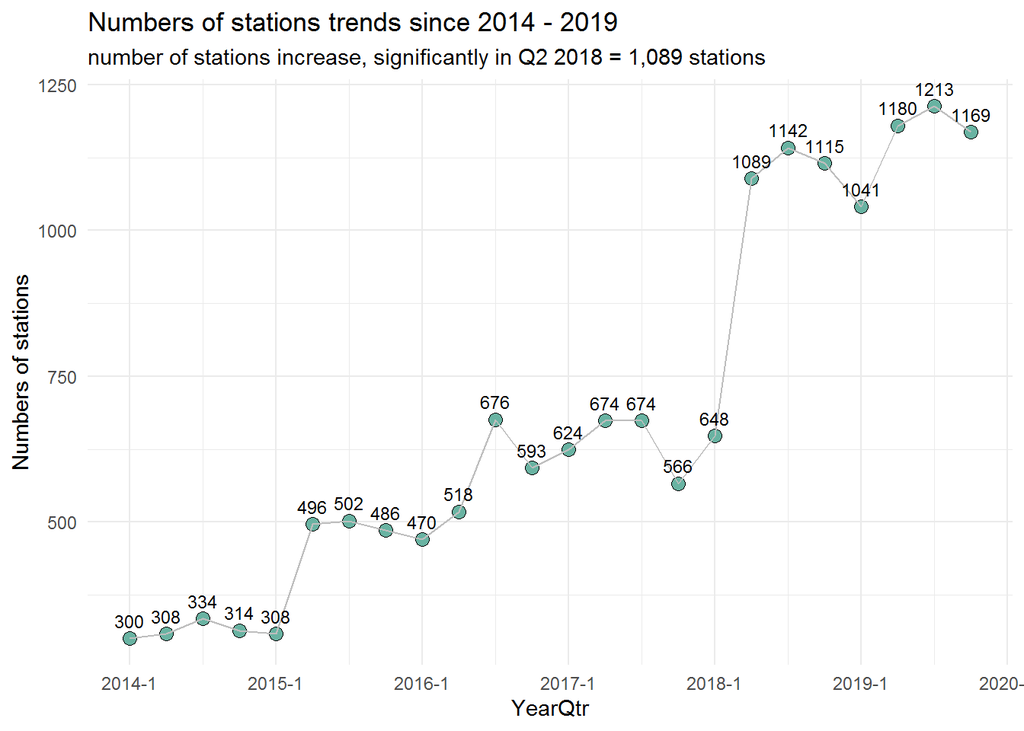

```r
combine_df_2014_to_2019_v3 %>% group_by(yearqtr) %>%
    summarize(number_of_stations=sum(number_of_stations)) %>%
    ggplot(mapping = aes(x = yearqtr, y= number_of_stations )) +
    geom_point(shape=21, color="black", fill="#69b3a2", size=3) +
    geom_line(color="grey") +
    labs(title = "Numbers of stations trends since 2014 - 2019",
         subtitle = "number of stations increase, significantly in Q2 2018 = 1,089 stations",
         x = "YearQtr",
         y = "Numbers of stations") +
    geom_text(aes(label = number_of_stations), vjust = -0.8, size = 3)
```

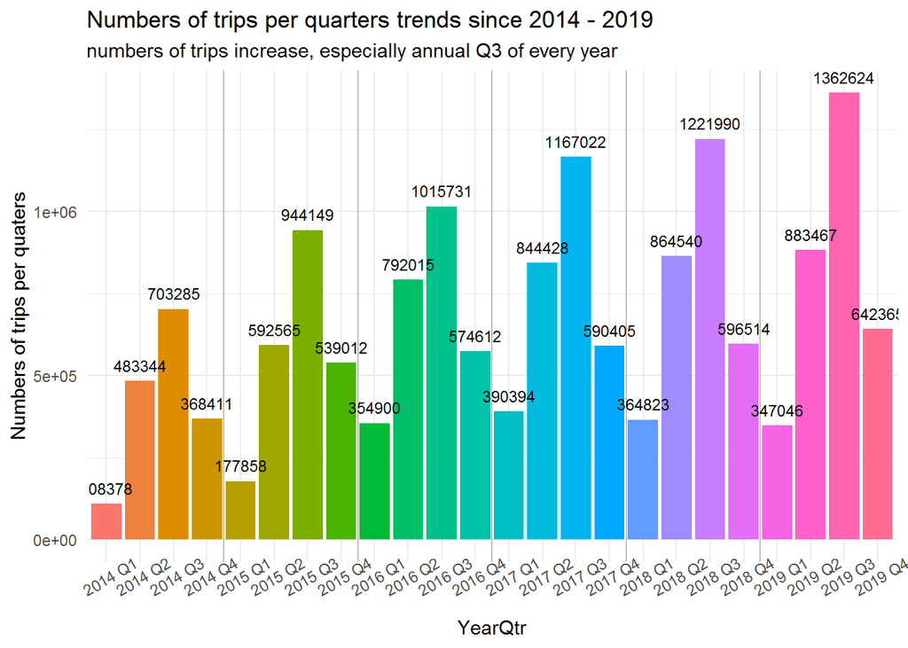

```r
combine_df_2014_to_2019_v3 %>%
    mutate(yearqtr = as.character(yearqtr)) %>%
    group_by(yearqtr) %>%
    summarize(number_of_trips_per_qtr=sum(number_of_trips_per_qtr)) %>%
    ggplot(mapping = aes(x = yearqtr, y= number_of_trips_per_qtr, fill = yearqtr)) +
    geom_col() +
    theme(axis.text.x = element_text(angle = 30), legend.position = "none") +
    geom_vline(xintercept = c(4.5, 8.5, 12.5, 16.5, 20.5), colour ="grey") +
    labs(title = "Numbers of trips per quarters trends since 2014 - 2019",
         subtitle = "numbers of trips increase, especially annual Q3 of every year",
         x = "YearQtr",
         y = "Numbers of trips per quaters") +
    geom_text(aes(label = number_of_trips_per_qtr), vjust = -0.8, hjust = 0.5, size = 3)
```

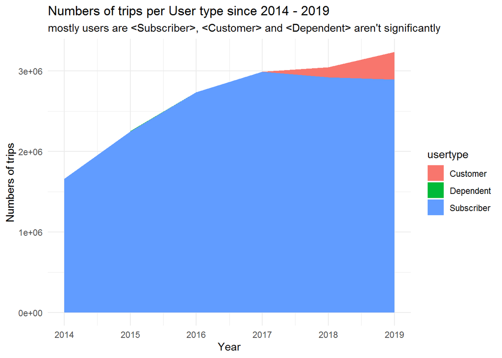

```r
combine_df_2014_to_2019_v3 %>%
    mutate(year = year(yearqtr)) %>%
    group_by(usertype,year) %>%
    summarize(number_of_trips_per_qtr=sum(number_of_trips_per_qtr)) %>%
    ggplot(mapping = aes(x = year, y= number_of_trips_per_qtr, fill = usertype  )) +
    geom_area() +
    labs(title = "Numbers of trips per User type since 2014 - 2019",
         subtitle = "mostly users are <Subscriber>, <Customer> and <Dependent> aren't significantly " ,
         x = "Year",
         y = "Numbers of trips")
```

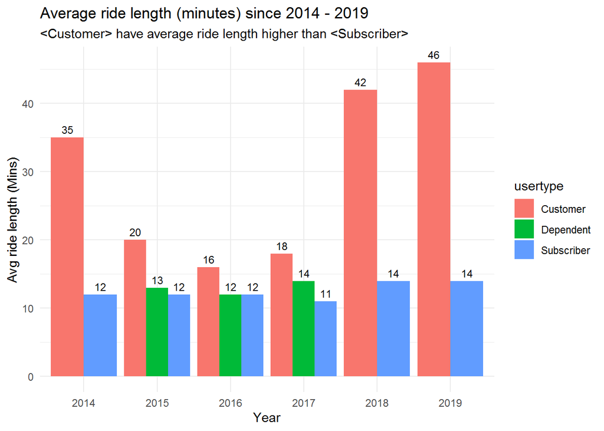

```r
combine_df_2014_to_2019_v3 %>%
    mutate(year = year(yearqtr)) %>%
    mutate(year = as.character(year)) %>%
    group_by(usertype,year) %>%
    summarize(avg_ride_length_mins = round(mean(avg_ride_length_mins))) %>%
    ggplot(mapping = aes(x = year, y= avg_ride_length_mins, fill = usertype)) +
    geom_col(position = "dodge") +
    labs(title = "Average ride length (minutes) since 2014 - 2019",
         subtitle = "<Customer> have average ride length higher than <Subscriber>",
         x = "Year",
         y = "Avg ride length (Mins)") +
    geom_text(aes(label = avg_ride_length_mins), position = position_dodge(0.9), vjust = -0.5, size = 3)
```

### Analyzing the Cyclistic bike trip data 2020

### 1.Number of trips 2020

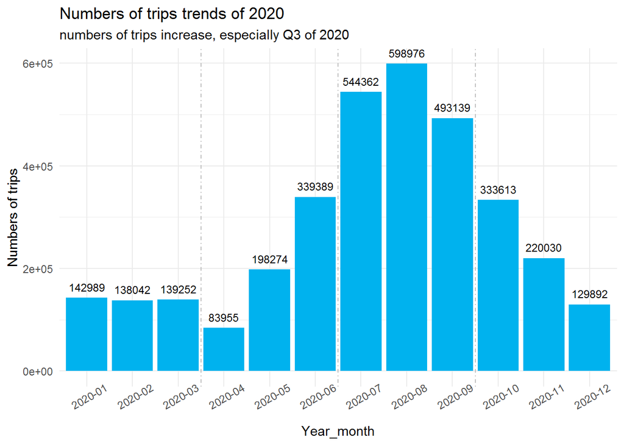

```r
#Numbers of trips trends of 2020
trips_2020_v2 %>%
    mutate(year_month = substr(started_at, 1,7)) %>%
    group_by(year_month) %>%
    summarize(number_of_trips = n()) %>%
    ggplot(mapping = aes(x = year_month, y = number_of_trips)) +
    geom_col(fill = "deepskyblue2") +
    theme(axis.text.x = element_text(angle = 30)) +
    geom_vline(xintercept = c(3.5, 6.5, 9.5), colour ="grey", linetype="dotdash") +
    labs(title = "Numbers of trips trends of 2020",
         subtitle = "numbers of trips increase, especially Q3 of 2020",
         x = "Year_month",
         y = "Numbers of trips") +
    geom_text(aes(label = number_of_trips), vjust = -0.8, hjust = 0.5, size = 3)
```

```r
#glimpse(trips_2020_v2)
```

```r
#filter dataframe only Q3 of 2020
trips_2020_Q3_v2 <- trips_2020_v2 %>%
                 mutate(yearqtr = as.yearqtr(started_at)) %>%
                 filter(yearqtr == "2020 Q3")
#glimpse(trips_2020_Q3_v2)
```

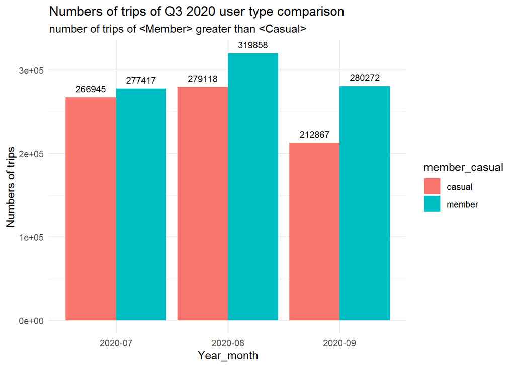

```r
#Numbers of trips of Q32020 usertype comparison
trips_2020_Q3_v2 %>%
    mutate(year_month = substr(started_at, 1,7)) %>%
    group_by(year_month, member_casual) %>%
    summarize(number_of_trips = n()) %>%
    ggplot(mapping = aes(x = year_month, y = number_of_trips, fill = member_casual)) +
    geom_col(position = 'dodge') +
    labs(title = "Numbers of trips of Q3 2020 user type comparison",
         subtitle = "number of trips of <Member> greater than <Casual>",
         x = "Year_month",
         y = "Numbers of trips") +
    geom_text(aes(label = number_of_trips), position = position_dodge(0.9),
              vjust = -0.8, hjust = 0.5, size = 3)
```

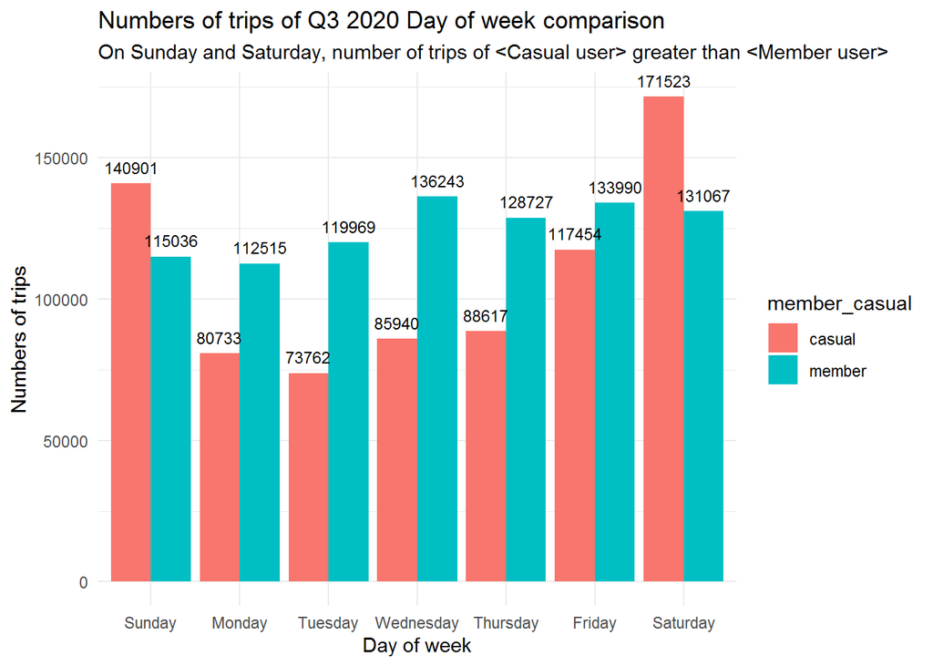

```r
#Numbers of trips of Q32020 Day of week comparison
trips_2020_Q3_v2 %>%
    mutate(year_month = substr(started_at, 1,7)) %>%
    group_by(day_of_week, member_casual) %>%
    summarize(number_of_trips = n()) %>%
    ggplot(mapping = aes(x = day_of_week, y = number_of_trips, fill = member_casual)) +
    geom_col(position = 'dodge') +
    #facet_wrap(~member_casual) +
    labs(title = "Numbers of trips of Q3 2020 Day of week comparison",
         subtitle = "On Sunday and Saturday, number of trips of <Casual user> greater than <Member user> ",
         x = "Day of week",
         y = "Numbers of trips") +
    geom_text(aes(label = number_of_trips), position = position_dodge(0.9),
              vjust = -0.8, hjust = 0.5, size = 3)
```

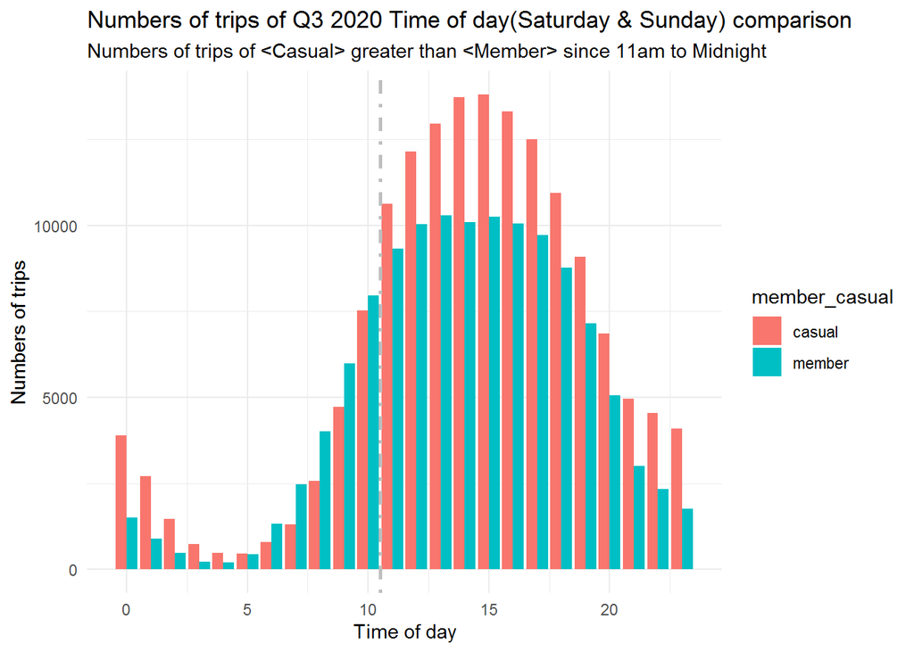

```r
#Numbers of trips of Q32020 time of day comparison
trips_2020_Q3_v2 %>%
    filter(day_of_week == c("Saturday", "Sunday")) %>%
    mutate(hours = hour(started_at)) %>%
    group_by(hours, member_casual) %>%
    summarize(number_of_trips = n()) %>%
    ggplot(mapping = aes(x = hours, y = number_of_trips, fill = member_casual)) +
    geom_col(position = 'dodge') +
    geom_vline(xintercept = 10.5, colour ="gray", size = 1, linetype="dotdash") +
    labs(title = "Numbers of trips of Q3 2020 Time of day(Saturday & Sunday) comparison",
         subtitle = "Numbers of trips of <Casual> greater than <Member> since 11am to Midnight" ,
         x = "Time of day",
         y = "Numbers of trips")
```

```r
#glimpse(trips_2020_v2)
```

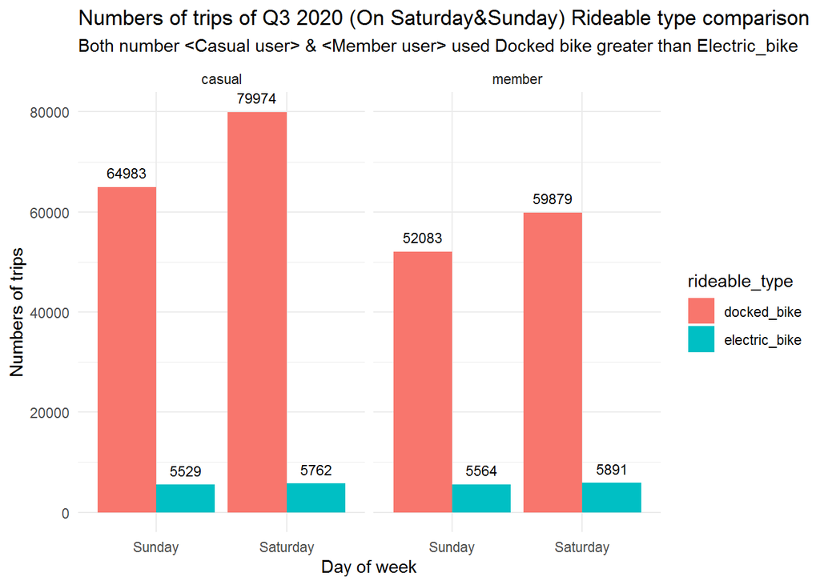

```r
#Numbers of trips of Q32020 rideable_type comparison
trips_2020_Q3_v2 %>%
    filter(day_of_week == c("Saturday", "Sunday")) %>%
    #mutate(year_month = substr(started_at, 1,7)) %>%
    group_by(day_of_week, member_casual,rideable_type) %>%
    summarize(number_of_trips = n()) %>%
    ggplot(mapping = aes(x = day_of_week, y = number_of_trips, fill = rideable_type)) +
    geom_col(position = 'dodge') +
    facet_wrap(~member_casual) +
    labs(title = "Numbers of trips of Q3 2020 (On Saturday&Sunday) Rideable type comparison",
         subtitle = "Both number <Casual user> & <Member user> used Docked bike greater than Electric_bike",
         x = "Day of week",
         y = "Numbers of trips") +
    geom_text(aes(label = number_of_trips), position = position_dodge(0.9),
              vjust = -0.8, hjust = 0.5, size = 3)
```

### Interpretation number of trips in 2020

- On Q3 2020 have highest `number of trips`
- On Q3 2020 `number of trips` of “Member” greater than “Casual”
- On Sunday and Saturday, `number of trips` of “Casual user” greater than “Member user”
- `Numbers of trips` on Sunday and Saturday, “Casual” greater than “Member” since 11am to Midnight
- Both “Casual” and “Member” user used `Docked Bike` greater than `Electric bike`

### 2.Average ride length of 2020

```r
#Summary()
trips_2020_v2 %>%
  select(ride_length_mins) %>%
  mutate(ride_length_mins = as.integer(ride_length_mins)) %>%
  summary()
```

```
##  ride_length_mins
##  Min.   :     1.00
##  1st Qu.:     8.00
##  Median :    14.00
##  Mean   :    28.26
##  3rd Qu.:    26.00
##  Max.   :156450.00
```

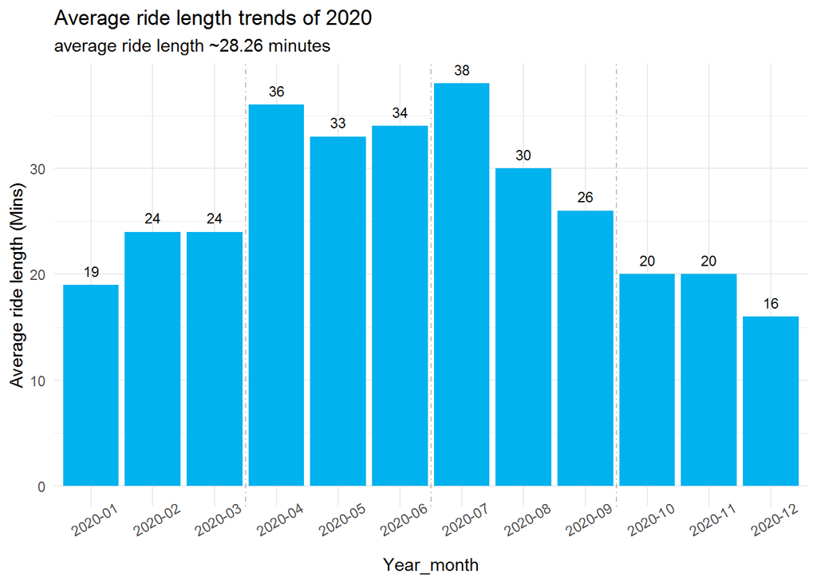

```r
#Average ride length trends of 2020
trips_2020_v2 %>%
    mutate(year_month = substr(started_at, 1,7)) %>%
    group_by(year_month) %>%
    summarize(avg_ride_length_mins = round(mean(ride_length_mins))) %>%
    ggplot(mapping = aes(x = year_month, y = avg_ride_length_mins)) +
    geom_col(fill = "deepskyblue2") +
    theme(axis.text.x = element_text(angle = 30)) +
    geom_vline(xintercept = c(3.5, 6.5, 9.5), colour ="grey", linetype="dotdash") +
    labs(title = "Average ride length trends of 2020",
         subtitle = "average ride length ~28.26 minutes",
         x = "Year_month",
         y = "Average ride length (Mins)") +
    geom_text(aes(label = avg_ride_length_mins), vjust = -0.8, hjust = 0.5, size = 3)
```

```r
#Summary of casual
trips_2020_v2 %>%
  select(ride_length_mins, member_casual) %>%
  filter(member_casual == 'casual') %>%
  mutate(ride_length_mins = as.integer(ride_length_mins)) %>%
  summary()
```

```
##  ride_length_mins   member_casual
##  Min.   :     1.0   Length:1290073
##  1st Qu.:    12.0   Class :character
##  Median :    22.0   Mode  :character
##  Mean   :    48.3
##  3rd Qu.:    42.0
##  Max.   :156450.0
```

```r
#Summary of member
trips_2020_v2 %>%
  select(ride_length_mins, member_casual) %>%
  filter(member_casual == 'member') %>%
  mutate(ride_length_mins = as.integer(ride_length_mins)) %>%
  summary()
```

```
##  ride_length_mins   member_casual
##  Min.   :    1.00   Length:2071840
##  1st Qu.:    7.00   Class :character
##  Median :   11.00   Mode  :character
##  Mean   :   15.78
##  3rd Qu.:   20.00
##  Max.   :93794.00
```

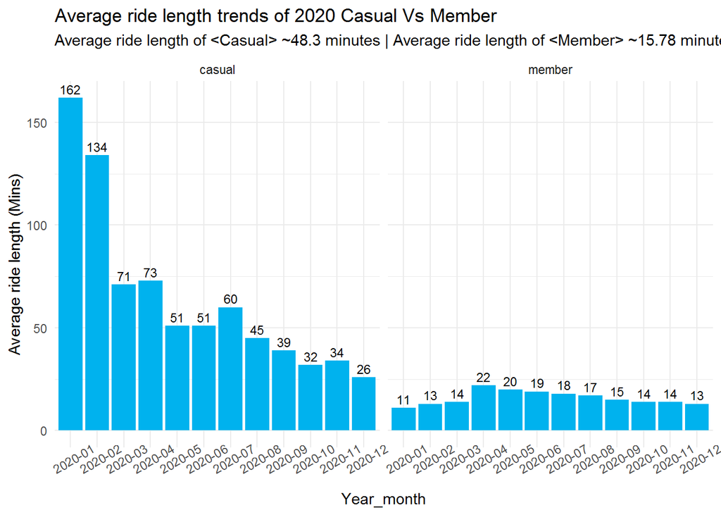

```r
#Average ride length trends of 2020 casual Vs member
trips_2020_v2 %>%
    mutate(year_month = substr(started_at, 1,7)) %>%
    group_by(year_month, member_casual) %>%
    summarize(avg_ride_length_mins = round(mean(ride_length_mins))) %>%
    ggplot(mapping = aes(x = year_month, y = avg_ride_length_mins)) +
    geom_col(fill = "deepskyblue2") +
    facet_wrap(~member_casual) +
    theme(axis.text.x = element_text(angle = 30)) +
    #geom_vline(xintercept = c(3.5, 6.5, 9.5), colour ="grey", linetype="dotdash") +
    labs(title = "Average ride length trends of 2020 Casual Vs Member",
         subtitle = "Average ride length of <Casual> ~48.3 minutes | Average ride length of <Member> ~15.78 minutes",
         x = "Year_month",
         y = "Average ride length (Mins)") +
    geom_text(aes(label = avg_ride_length_mins), vjust = -0.4, hjust = 0.5, size = 3)
```

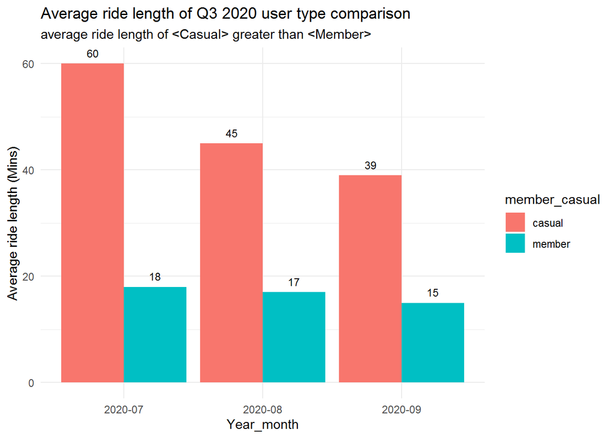

```r
#Average ride length of Q32020 user type comparison
trips_2020_Q3_v2 %>%
    mutate(year_month = substr(started_at, 1,7)) %>%
    group_by(year_month, member_casual) %>%
    summarize(avg_ride_length_mins = round(mean(ride_length_mins))) %>%
    ggplot(mapping = aes(x = year_month, y = avg_ride_length_mins, fill = member_casual)) +
    geom_col(position = 'dodge') +
    labs(title = "Average ride length of Q3 2020 user type comparison",
         subtitle = "average ride length of <Casual> greater than <Member>",
         x = "Year_month",
         y = "Average ride length (Mins)") +
    geom_text(aes(label = avg_ride_length_mins), position = position_dodge(0.9),
              vjust = -0.8, hjust = 0.5, size = 3)
```

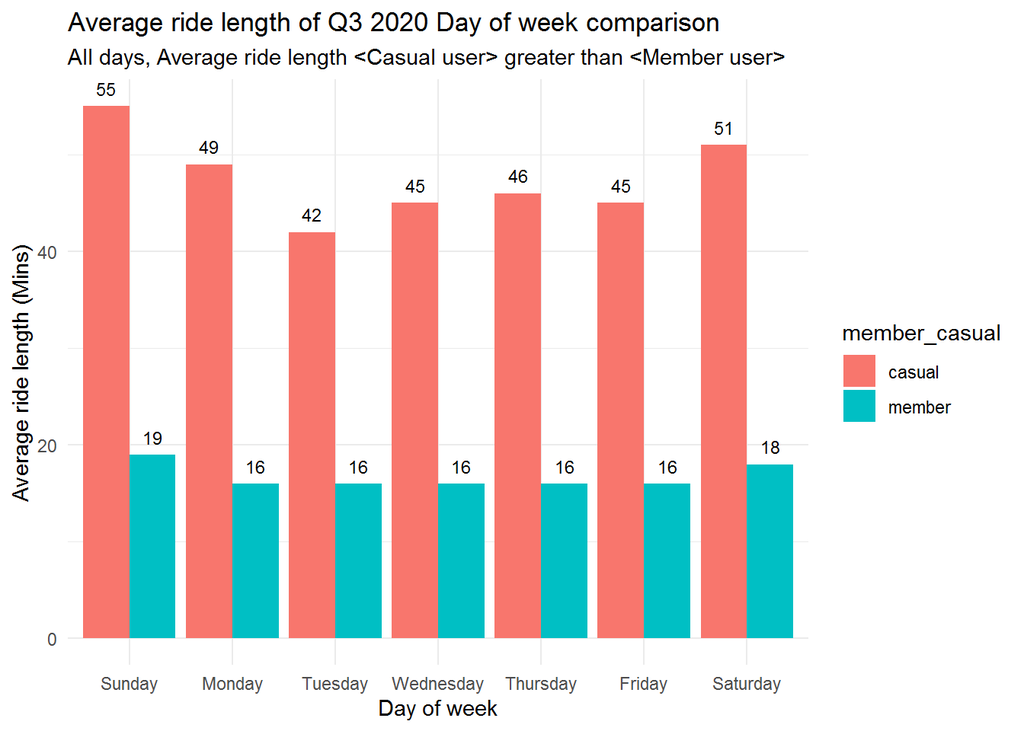

```r
#Average ride length of Q32020 Day of week comparison
trips_2020_Q3_v2 %>%
    mutate(year_month = substr(started_at, 1,7)) %>%
    group_by(day_of_week, member_casual) %>%
    summarize(avg_ride_length_mins = round(mean(ride_length_mins))) %>%
    ggplot(mapping = aes(x = day_of_week, y = avg_ride_length_mins, fill = member_casual)) +
    geom_col(position = 'dodge') +
    #facet_wrap(~member_casual) +
    labs(title = "Average ride length of Q3 2020 Day of week comparison",
         subtitle = "All days, Average ride length <Casual user> greater than <Member user> ",
         x = "Day of week",
         y = "Average ride length (Mins)") +
    geom_text(aes(label = avg_ride_length_mins), position = position_dodge(0.9),
              vjust = -0.8, hjust = 0.5, size = 3)
```

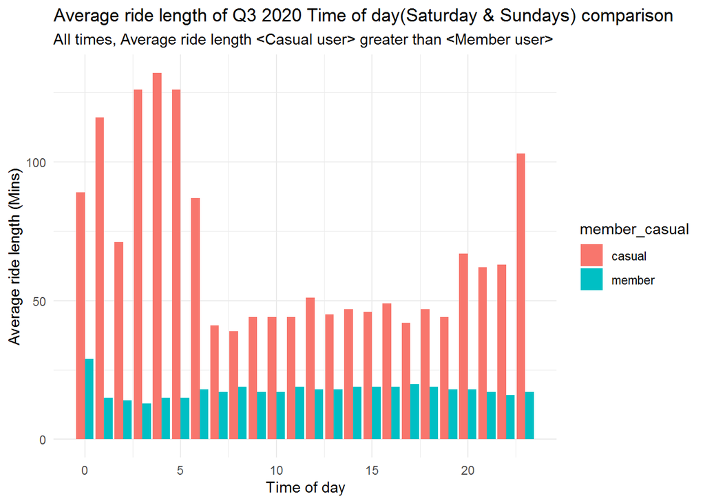

```r
#Average ride length of Q32020 time of day comparison
trips_2020_Q3_v2 %>%
    filter(day_of_week == c("Saturday", "Sunday")) %>%
    mutate(hours = hour(started_at)) %>%
    group_by(hours, member_casual) %>%
    summarize(avg_ride_length_mins = round(mean(ride_length_mins))) %>%
    ggplot(mapping = aes(x = hours, y = avg_ride_length_mins, fill = member_casual)) +
    geom_col(position = 'dodge') +
    #geom_vline(xintercept = 10.5, colour ="gray", size = 1, linetype="dotdash") +
    labs(title = "Average ride length of Q3 2020 Time of day(Saturday & Sundays) comparison",
         subtitle = "All times, Average ride length <Casual user> greater than <Member user> " ,
         x = "Time of day",
         y = "Average ride length (Mins)")
```

### Interpretation Average ride length in 2020

- `Average ride length` of “Casual” higher than “Member”
- `Average ride length` of “Casual” ~48.3 minutes | `Average ride length` of “Member” ~15.78 minutes

```r
#glimpse(trips_2020_v2)
```

### 3.Top 5 route of Cyclistic bike in 2020

```r
#number of trips per route bike
trips_2020_v3 <- trips_2020_v2 %>%
                 unite(start_end_id, c("start_station_id", "end_station_id"), sep = "_", na.rm = TRUE) %>%
                 select(start_end_id, start_station_name, end_station_name,
                        member_casual, start_lat, start_lng) %>%
                 mutate(start_lat = round(start_lat, 3), start_lng = round(start_lng,3))%>%
                 group_by(start_end_id,start_station_name, end_station_name,
                          member_casual, start_lat, start_lng) %>%
                 summarize(number_of_trips = n()) %>%
                 unite(label, c("start_station_name", "number_of_trips"),
                       sep = "=", na.rm = TRUE, remove = FALSE) %>%
                 arrange(-number_of_trips)
#glimpse(trips_2020_v3)
```

#### Top 5 route of Cyclistic bike of “Casual” in 2020

| start_end_id | start_station_name | end_station_name | member_casual | start_lat | start_lng | number_of_trips |
| --- | --- | --- | --- | --- | --- | --- |
| 35_35 | Streeter Dr & Grand Ave | Streeter Dr & Grand Ave | casual | 41.892 | -87.612 | 5615 |
| 76_76 | Lake Shore Dr & Monroe St | Lake Shore Dr & Monroe St | casual | 41.881 | -87.617 | 5421 |
| 90_90 | Millennium Park | Millennium Park | casual | 41.881 | -87.624 | 4511 |
| 2_2 | Buckingham Fountain | Buckingham Fountain | casual | 41.877 | -87.621 | 4142 |
| 255_255 | Indiana Ave & Roosevelt Rd | Indiana Ave & Roosevelt Rd | casual | 41.868 | -87.623 | 3588 |

```r
#glimpse(trips_2020_v3_casual)
```

```r
### visualization

trips_2020_v3 %>%
  filter(member_casual == 'casual') %>%
  arrange(-number_of_trips) %>%
  head(5) %>%
  leaflet() %>%
  addTiles() %>%  # use the default base map which is OpenStreetMap tiles
  addMarkers(lng = ~start_lng, lat = ~start_lat, label = ~label,
             labelOptions = labelOptions(noHide = FALSE))
```

[interactive chart not shown]

#### Top 5 route of Cyclistic bike of “Member” in 2020

| start_end_id | start_station_name | end_station_name | member_casual | start_lat | start_lng | number_of_trips |
| --- | --- | --- | --- | --- | --- | --- |
| 237_148 | MLK Jr Dr & 29th St | State St & 33rd St | member | 41.842 | -87.617 | 1084 |
| 157_157 | Lake Shore Dr & Wellington Ave | Lake Shore Dr & Wellington Ave | member | 41.937 | -87.637 | 935 |
| 148_237 | State St & 33rd St | MLK Jr Dr & 29th St | member | 41.835 | -87.626 | 924 |
| 4_4 | Burnham Harbor | Burnham Harbor | member | 41.856 | -87.613 | 864 |
| 334_334 | Lake Shore Dr & Belmont Ave | Lake Shore Dr & Belmont Ave | member | 41.941 | -87.639 | 858 |

```r
### visualization
trips_2020_v3 %>%
  filter(member_casual == 'member') %>%
  arrange(-number_of_trips) %>%
  head(5) %>%
  leaflet() %>%
  addTiles() %>%  # use the default base map which is OpenStreetMap tiles
  addMarkers(lng = ~start_lng, lat = ~start_lat, label = ~label,
             labelOptions = labelOptions(noHide = FALSE))
```

[interactive chart not shown]

### Conclusion

#### From Historical bike data since 2014-2019 represent

- `numbers of trips` increase every year, especially annual `Third Quarter (Q3)`
- mostly user is “Subscriber(member)”
- `average ride length (minutes)` Casual(usertype = Customer and Dependent) higher than Subscriber(member)

#### From 2020 bike data represent

- on Q3 2020 have highest `number of trips`
- on Q3 2020 `number of trips` of “Member” greater than “Casual”
- on Sunday and Saturday, `number of trips` of “Casual user” greater than “Member user”
- `Numbers of trips` on Sunday and Saturday, “Casual” greater than “Member” since 11am to Midnight
- `Average ride length` of “Casual” higher than “Member”
- `Average ride length` of Casual ~48.3 minutes | `Average ride length` of Member ~15.78 minutes

#### Top 5 route of Cyclistic bike of “Casual”

```r
knitr::kable(head(trips_2020_v3_casual, 5))
```

| start_end_id | start_station_name | end_station_name | member_casual | start_lat | start_lng | number_of_trips |
| --- | --- | --- | --- | --- | --- | --- |
| 35_35 | Streeter Dr & Grand Ave | Streeter Dr & Grand Ave | casual | 41.892 | -87.612 | 5615 |
| 76_76 | Lake Shore Dr & Monroe St | Lake Shore Dr & Monroe St | casual | 41.881 | -87.617 | 5421 |
| 90_90 | Millennium Park | Millennium Park | casual | 41.881 | -87.624 | 4511 |
| 2_2 | Buckingham Fountain | Buckingham Fountain | casual | 41.877 | -87.621 | 4142 |
| 255_255 | Indiana Ave & Roosevelt Rd | Indiana Ave & Roosevelt Rd | casual | 41.868 | -87.623 | 3588 |

### Recommendation

- Goal: Design marketing strategies aimed at converting Casual riders into Annual members
- As we know, On Sunday and Saturday `number of trips` of Casual user greater than Member user
- and know about Top 5 route of Cyclistic bike of “Casual”
- So, you can apply insights finding with digital media to lunch promotion convert `casual riders` to `annual members`

### Appendix

- Dataset
  - https://divvy-tripdata.s3.amazonaws.com/index.html